# STA 5331: Homework 4

Brandon Owens

2024-03-13

```r
library(ggplot2)
library(dplyr)
p1 <- c(11, 17, 16, 14, 15)
p2 <- c(12, 10, 15, 19, 11)
p3 <- c(23, 20, 18, 17)
p4 <- c(27, 33, 22, 26, 28)

sigma <- 3.25
```

# Part IIa:

```r
p1_sample_mean <- mean(p1)
p2_sample_mean <- mean(p2)
p3_sample_mean <- mean(p3)
p4_sample_mean <- mean(p4)

p1_std_error <- sigma / sqrt(length(p1))
p2_std_error <- sigma / sqrt(length(p2))
p3_std_error <- sigma / sqrt(length(p3))
p4_std_error <- sigma / sqrt(length(p4))

package_means <- c(p1_sample_mean, p2_sample_mean, p3_sample_mean, p4_sample_mean)
package_std_errors <- c(p1_std_error, p2_std_error, p3_std_error, p4_std_error)
```

> - **“Package 1 Mean: 14.6”**
> - **“Package 2 Mean: 13.4”**
> - **“Package 3 Mean: 19.5”**
> - **“Package 4 Mean: 27.2”**
> - **“Package 1 Std. Error: 1.45344418537486”**
> - **“Package 2 Std. Error: 1.45344418537486”**
> - **“Package 3 Std. Error: 1.625”**
> - **“Package 4 Std. Error: 1.45344418537486”**

# Part IIb:

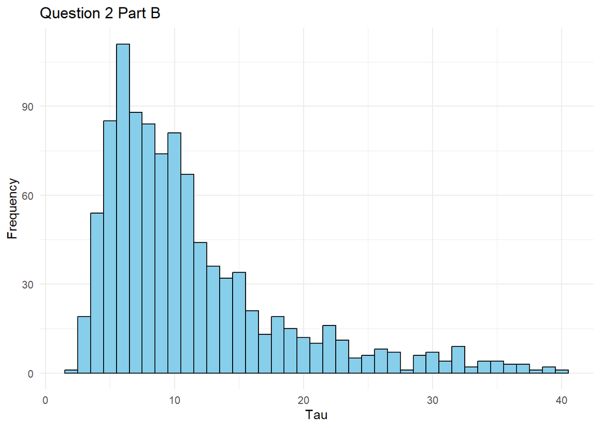

```r
package_std_errors <- package_std_errors^2

mu_hat <- function(tau, y, variance){
  sum(y/(variance + tau^2))/sum(1/(variance + tau^2))
}

V_mu <- function(tau, y, variance){
  1/sum(1/(tau^2 + variance))
}

n_grid <- 2000
tau_grid <- seq(.01, 40, length = n_grid)
log_p_tau <- rep(NA, n_grid)

for (i in 1:n_grid){
  mu <- mu_hat(tau_grid[i], package_means, package_std_errors)
  V <- V_mu(tau_grid[i], package_means, package_std_errors)
  log_p_tau[i] <- .5*log(V) - .5*sum(log(package_std_errors + tau_grid[i]^2)) - .5*sum((package_means - mu)^2/(package_std_errors + tau_grid[i]^2))
}

log_p_tau <- log_p_tau - max(log_p_tau)
p_tau <- exp(log_p_tau)
p_tau <- p_tau/sum(p_tau)
n_sims <- 1000

tau <- sample(tau_grid, n_sims, replace=TRUE, prob=p_tau)

marg_post_tau <- ggplot(data = NULL, aes(x = tau)) +
  geom_histogram(binwidth = 1, fill = "skyblue", color = "black") +
  labs(title = "Question 2 Part B", x = "Tau", y = "Frequency") +
  theme_minimal()

marg_post_tau
```

> **The histogram appears to have the largest frequency of values (mode) where tau is around 5 to 7. It almost looks like a normal distribution itself that has been skewed right with a pretty long tail.**

# Part IIc:

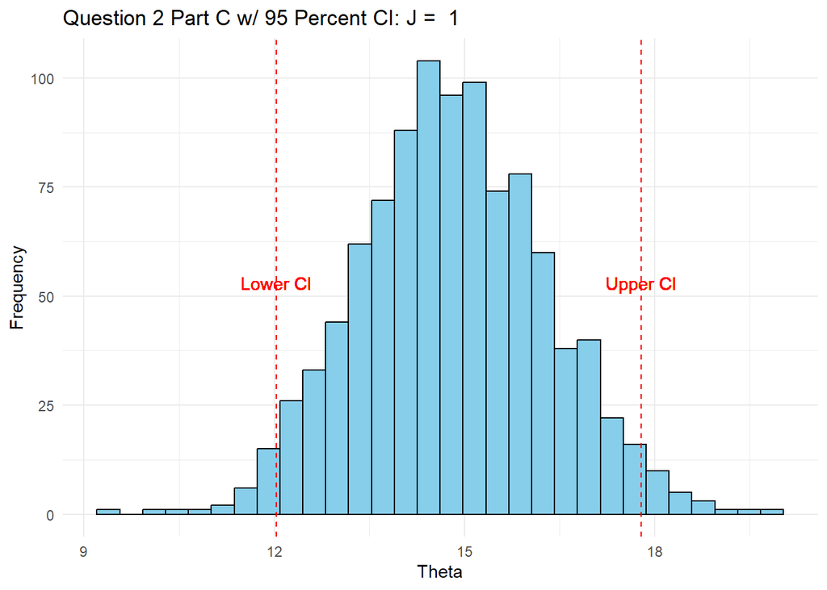

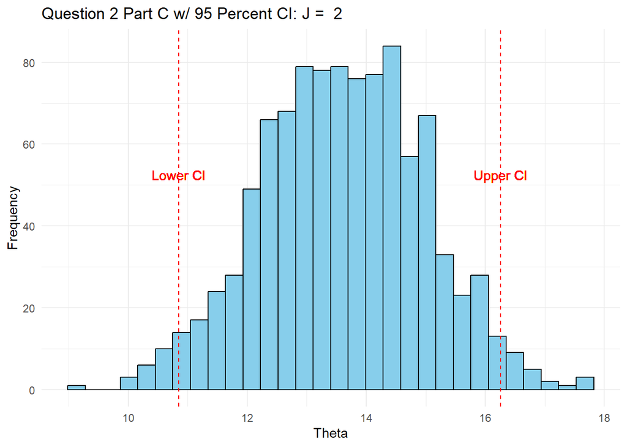

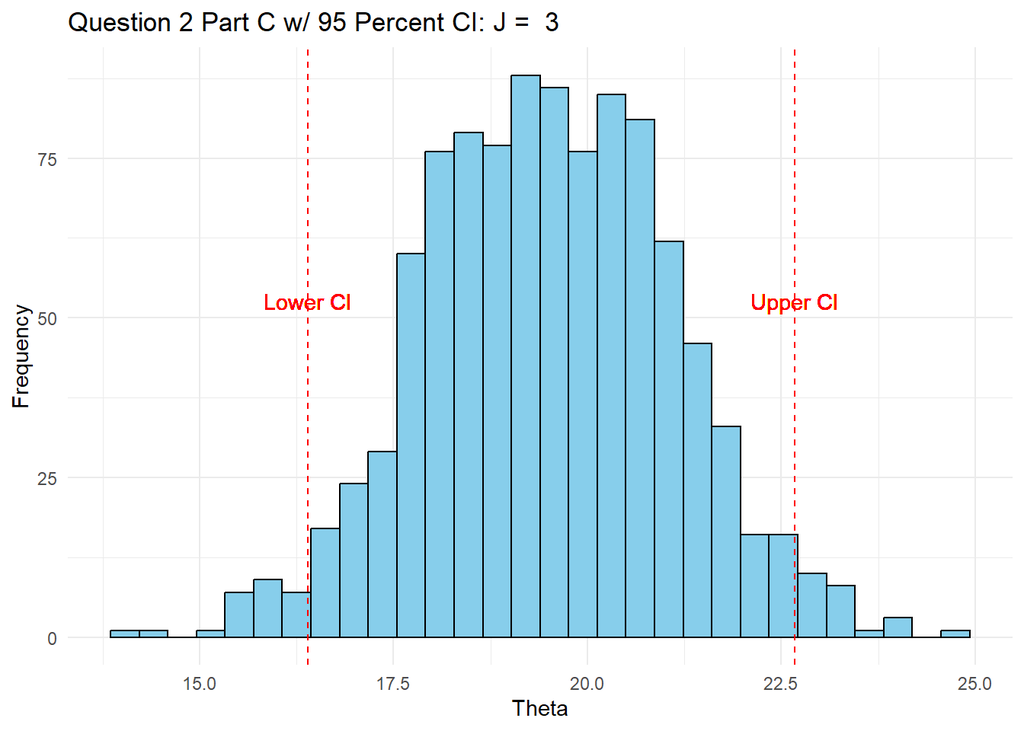

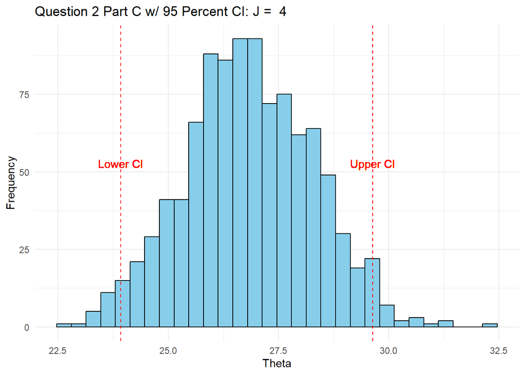

```r
J <- 4
mu <- rep(NA, n_sims)
theta <- array(NA, c(n_sims, J))
CI <- array(NA, c(J, 2))

for (i in 1:n_sims){
  mu[i] <- rnorm(1, mu_hat(tau[i], package_means, package_std_errors), sqrt(V_mu(tau[i], package_means, package_std_errors)))
  theta_mean <- (mu[i]/tau[i]^2 + package_means/package_std_errors)/(1/tau[i]^2 + 1/package_std_errors)
  theta_sd <- sqrt(1/(1/tau[i]^2 + 1/package_std_errors))
  theta[i,] <- rnorm(J, theta_mean, theta_sd)
}

for (i in 1:J){
  CI[i,] <- quantile(theta[,i], probs = c(0.025, 0.975))
  post_theta <- ggplot(data = data.frame(theta = theta[,i]), aes(x = theta)) +
    geom_histogram(fill = "skyblue", color = "black") +
    geom_vline(aes(xintercept = CI[i, 1]), color = "red", linetype = "dashed") +
    geom_vline(aes(xintercept = CI[i, 2]), color = "red", linetype = "dashed") +
    geom_text(aes(x = CI[i, 1], label = "Lower CI"), y = 50, vjust = -0.5, color = "red") +
    geom_text(aes(x = CI[i, 2], label = "Upper CI"), y = 50, vjust = -0.5, color = "red") +
    labs(title = paste("Question 2 Part C w/ 95 Percent CI: J = ", i), x = "Theta", y = "Frequency") +
    theme_minimal()
  print(post_theta)
}
```

> **The leading package would be the fourth package in this case. It’s mean sales at the end of the study is around 26 to 28 and although it has a decent amount of variability, its 95% confidence interval’s lower bound is higher than any of the other package’s means.**

# Part IId:

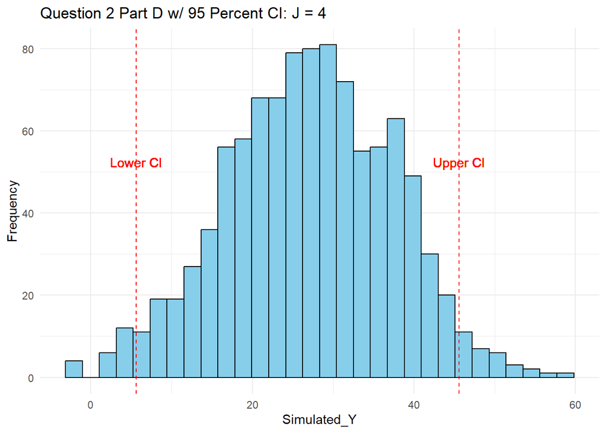

```r
y_draws <- rep(NA, n_sims)
theta_j_draw = sample(theta[,4], size = 1)
y_draws <- rnorm(n_sims, theta_j_draw, sigma^2)
simulated_mean <- mean(y_draws)
simulated_variance <- var(y_draws)/n_sims

for (i in 1:n_grid){
  mu <- mu_hat(tau_grid[i], simulated_mean, simulated_variance)
  V <- V_mu(tau_grid[i], simulated_mean, simulated_variance)
  log_p_tau[i] <- .5*log(V) - .5*sum(log(simulated_variance + tau_grid[i]^2)) - .5*sum((simulated_mean - mu)^2/(simulated_variance + tau_grid[i]^2))
}

log_p_tau <- log_p_tau - max(log_p_tau)
p_tau <- exp(log_p_tau)
p_tau <- p_tau/sum(p_tau)
sim_tau <- sample(tau_grid, n_sims, replace=TRUE, prob=p_tau)

sim_theta <- rep(NA, n_sims)

for (i in 1:n_sims){
  mu[i] <- rnorm(1, mu_hat(sim_tau[i], simulated_mean, simulated_variance), sqrt(V_mu(sim_tau[i], simulated_mean, simulated_variance)))
  theta_mean <- (mu[i]/sim_tau[i]^2 + simulated_mean/simulated_variance)/(1/sim_tau[i]^2 + 1/simulated_variance)
  theta_sd <- sqrt(1/(1/sim_tau[i]^2 + 1/simulated_mean))
  sim_theta[i] <- rnorm(1, theta_mean, theta_sd)
}


theta_tilde <- mean(sim_theta[i])
simulated_y <- rnorm(n_sims, theta_tilde, sigma^2)
CI <- quantile(simulated_y, probs = c(0.025, 0.975))

post_pred_y <- ggplot(data = data.frame(simulated_y = simulated_y), aes(x = simulated_y)) +
    geom_histogram(fill = "skyblue", color = "black") +
    geom_vline(aes(xintercept = CI[1]), color = "red", linetype = "dashed") +
    geom_vline(aes(xintercept = CI[2]), color = "red", linetype = "dashed") +
    geom_text(aes(x = CI[1], label = "Lower CI"), y = 50, vjust = -0.5, color = "red") +
    geom_text(aes(x = CI[2], label = "Upper CI"), y = 50, vjust = -0.5, color = "red") +
    labs(title = "Question 2 Part D w/ 95 Percent CI: J = 4", x = "Simulated_Y", y = "Frequency") +
    theme_minimal()

post_pred_y
```